# SIGNAL tutorial

SIGNAL (**S**patial var**I**able **G**ene detectio**N** **A**nd c**L**assification) detects spatially variable genes in single-cell resolution spatial transcriptomics and classifies each one by the source of its variation:

| Effect | Meaning |
| --- | --- |
| `CellType` | expression differs between cell types |
| `Spatial` | expression varies over space in the same way for all cell types |
| `ctSVG` | the spatial pattern is specific to some cell types |

This tutorial walks through a complete analysis of the example data shipped with the package.

## Installation

```r
if (!require("devtools", quietly = TRUE)) {
  install.packages("devtools")
}
devtools::install_github("tingthou/SIGNAL")
```

```r
library(SIGNAL)
```

## Example data

SIGNAL needs three inputs for the same set of cells:

- `counts`: a genes x cells matrix of raw counts (a base or sparse matrix);
- `location`: a cells x 2 matrix of spatial coordinates;
- `celltype`: a cell-type label for each cell.

`SIGNAL_example` is a simulated data set of 400 cells from four cell types and 70 genes. Genes 1-40 are null, genes 41-50 are higher in cell type CT1, genes 51-60 are higher in a central hotspot for every cell type, and genes 61-70 are higher in the hotspot for CT1 only (ctSVGs).

```r
data(SIGNAL_example)
counts <- SIGNAL_example$counts
location <- SIGNAL_example$location
celltype <- SIGNAL_example$celltype

dim(counts)
```

```
#> [1]  70 400
```

```r
head(location, 3)
```

```
#>               x           y
#> cell1 0.7326202 0.422270634
#> cell2 0.4757614 0.537601858
#> cell3 0.5142159 0.002191167
```

```r
table(celltype)
```

```
#> celltype
#> CT1 CT2 CT3 CT4
#>  99 100 103  98
```

## Step 1: create a SIGNAL object

```r
obj <- createSIGNALobject(counts = counts, location = location,
                          celltype = celltype, project = "Example")
obj
```

```
#> SIGNAL object: Example
#>   70 genes x 400 cells, 4 cell types
#>   Steps run: none
```

## Step 2: filter and transform expression

Genes expressed in fewer than `min_cells` cells are removed. Each remaining gene is converted to normal scores, `qnorm((rank(y) - 0.5) / n)`; tied counts, in particular the zeros, share their average rank, so the result is deterministic. `filter = "celina"` applies CELINA’s gene and cell filter instead, and `transform = "impute"` breaks tied zeros at random.

```r
obj <- SIGNAL_preprocess(obj, min_cells = 10)
```

## Step 3: build kernels

`SIGNAL_kernel()` builds the cell-type kernel and, from the coordinates, a panel of 11 spatial kernels. These are 5 Gaussian and 5 Matérn kernels at different scales, plus a thin-plate spline kernel. See `?build_spatial_kernels` for the definitions.

```r
obj <- SIGNAL_kernel(obj)
names(obj@spatial_kernels)
```

```
#>  [1] "gaussian_1" "matern_1"   "gaussian_2" "matern_2"   "gaussian_3"
#>  [6] "matern_3"   "gaussian_4" "matern_4"   "gaussian_5" "matern_5"
#> [11] "spline"
```

To use other spatial kernels, pass a list of n x n matrices: `SIGNAL_kernel(obj, kernels = my_kernels)`.

## Step 4: test and classify genes

For each gene and each spatial kernel, SIGNAL fits

$$y \sim N\left(0,\ \tau_1 K_{celltype} +
\tau_2 K_{spatial} + \tau_3 K_{interaction} + \sigma^2
I\right)$$

and computes four p-values:

- an **overall** test of $\tau_1 = \tau_2 = \tau_3 = 0$;
- a **cell-type** test ($\tau_1$), a **spatial** test ($\tau_2$) and a **ctSVG** test ($\tau_3$).

P-values are combined across the 11 kernels with the Cauchy combination test. By default (`method = "davies_liu"`), as in the original SIGNAL analysis code, the overall test’s tail probability uses Davies’ method and the cell-type, spatial and ctSVG tests use Liu’s moment-matching approximation.

```r
obj <- SIGNAL_test(obj, alpha = 0.05, adjust = "BH")
obj
```

```
#> SIGNAL object: Example
#>   70 genes x 400 cells, 4 cell types
#>   Steps run: preprocess, kernel, test
#>   11 spatial kernels
#>   70 genes tested; significant (BH-adjusted overall p < 0.05): 30
#>     cell-type effect: 21 | spatial effect: 15 | ctSVG: 10
```

```r
head(obj@result)
```

```
#>        gene  p_overall p_celltype  p_spatial    p_ctSVG padj_overall
#> gene1 gene1 0.96179774  0.5810178 0.46504830 0.97968958   0.99291255
#> gene2 gene2 0.04019524  0.1561524 0.32178381 0.06138018   0.09076344
#> gene3 gene3 0.39417392  0.3584508 0.42533821 0.39460493   0.53475510
#> gene4 gene4 0.44451921  0.1454569 0.44053588 0.52407120   0.56575172
#> gene5 gene5 0.56059044  0.4545342 0.20263685 0.67922102   0.67657466
#> gene6 gene6 0.15656836  0.2656148 0.08963233 0.29046443   0.30443847
#>       significant celltype_effect spatial_effect ctSVG_effect        category
#> gene1       FALSE           FALSE          FALSE        FALSE Not significant
#> gene2       FALSE           FALSE          FALSE        FALSE Not significant
#> gene3       FALSE           FALSE          FALSE        FALSE Not significant
#> gene4       FALSE           FALSE          FALSE        FALSE Not significant
#> gene5       FALSE           FALSE          FALSE        FALSE Not significant
#> gene6       FALSE           FALSE          FALSE        FALSE Not significant
```

Classification works in two steps. A gene is significant if its BH-adjusted overall p-value is below `alpha`. Each significant gene is then labelled with every effect whose own p-value is below `alpha`.

```r
summary(obj)
```

```
#> category
#>               CellType         CellType+ctSVG       CellType+Spatial
#>                     10                      5                      1
#> CellType+Spatial+ctSVG        Not significant                Spatial
#>                      5                     40                      9
```

Compare with the true gene types:

```r
table(truth = SIGNAL_example$gene_type[obj@result$gene],
      SIGNAL = obj@result$category)
```

```
#>           SIGNAL
#> truth      CellType CellType+ctSVG CellType+Spatial CellType+Spatial+ctSVG
#>   celltype       10              0                0                      0
#>   ctSVG           0              5                0                      5
#>   null            0              0                0                      0
#>   spatial         0              0                1                      0
#>           SIGNAL
#> truth      Not significant Spatial
#>   celltype               0       0
#>   ctSVG                  0       0
#>   null                  40       0
#>   spatial                0       9
```

To change the decision rule without refitting, call `SIGNAL_classify()`:

```r
obj_strict <- SIGNAL_classify(obj, alpha = 0.01, adjust = "bonferroni")
summary(obj_strict)
```

```
#> category
#>               CellType         CellType+ctSVG CellType+Spatial+ctSVG
#>                     10                      2                      2
#>                  ctSVG        Not significant                Spatial
#>                      2                     42                     10
#>          Spatial+ctSVG
#>                      2
```

## Visualise genes

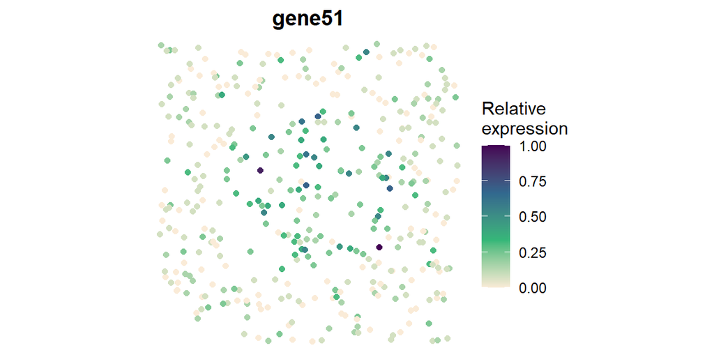

```r
SIGNAL_plotGene(obj, "gene51")
```

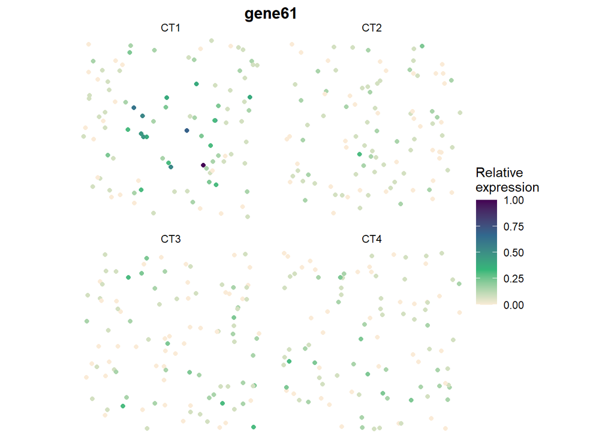

```r
SIGNAL_plotGene(obj, "gene61", by_celltype = TRUE)
```

`gene51` is high in the hotspot for every cell type. `gene61` is high in the hotspot only for CT1.

## Step 5: find the cell types behind each ctSVG

`SIGNAL_celltype()` tests each ctSVG once per cell type, using an interaction kernel built from that cell type alone. By default it tests the genes with a significant ctSVG effect from `SIGNAL_test()`.

```r
obj <- SIGNAL_celltype(obj)
signif(obj@celltype_result, 2)
```

```
#>            CT1  CT2  CT3  CT4
#> gene61 7.1e-10 0.99 0.31 0.55
#> gene62 3.3e-07 0.93 0.91 0.96
#> gene63 2.3e-05 0.50 0.92 0.80
#> gene64 1.2e-05 0.88 0.71 0.48
#> gene65 2.3e-05 0.38 0.52 0.84
#> gene66 1.6e-10 0.99 0.89 0.95
#> gene67 1.5e-07 0.69 0.91 0.94
#> gene68 1.2e-07 0.80 0.28 0.88
#> gene69 8.9e-09 0.54 0.63 0.68
#> gene70 2.2e-10 0.79 0.66 0.77
```

The small p-values are in the CT1 column, the cell type that carries the simulated pattern.

## One-step analysis

`SIGNAL()` runs steps 1-4 in one call:

```r
obj <- SIGNAL(counts, location, celltype)
```

## Large data sets

- With the default `method = "davies_liu"`, the overall test needs an n x n eigendecomposition per gene and kernel, so run time grows with both the number of cells n and the number of genes. For large data, split the genes into batches (for example one HPC job per batch) and run each batch with `SIGNAL()` on that subset of rows of `counts`.
- `method = "moment"` uses Liu’s approximation for all four tests, computed once per kernel. Its cost hardly depends on the number of genes, which makes it useful for a quick first pass.
- Memory holds the 11 spatial kernels plus working n x n matrices, a few GB at n = 5,000.
- On Linux or macOS, `SIGNAL_test(obj, ncores = k)` processes `k` spatial kernels in parallel. Each worker needs its own working memory.
- R linked to an optimised BLAS (OpenBLAS, Intel MKL, Apple Accelerate) speeds up the matrix products considerably.